# A Prediction Model Project in R

Bernardo Di Chiara

April 5, 2018

## 1. Introduction

This project consists on building and comparing different prediction models with the purpose of predicting the quality of physical activity based on a set of measured and calculated variables related to such activity.

## 2. Background

This project is based on the work published in the document below:

Velloso, E.; Bulling, A.; Gellersen, H.; Ugulino, W.; Fuks, H. “Qualitative Activity Recognition of Weight Lifting Exercises.” Proceedings of 4th International Conference in Cooperation with SIGCHI (Augmented Human ’13). Stuttgart, Germany: ACM SIGCHI, 2013.

http://groupware.les.inf.puc-rio.br/public/papers/2013.Velloso.QAR-WLE.pdf

It is a study about physical activity recognition. While most of similar projects usually focus on the quality of physical activity, this study aims to measure the quality of the movements.

Six participants (males, aged between 20-28 years, with little weight lifting experience) were provided with sensors (accelerometer, gyroscope and magnetometer) on four different points: belt, forearm, arm, and dumbell. Then they were asked to perform barbell lifts (Unilateral Dumbbell Biceps Curl) correctly and incorrectly in 5 different ways:

- Exactly according to the specification (Class A)
- Throwing the elbows to the front (Class B)
- Lifting the dumbbell only halfway (Class C)
- Lowering the dumbbell only halfway (Class D)
- Throwing the hips to the front (Class E)

Classes B to E cover the most common mistakes. Participants were supervised by an experienced weight lifter to make sure the execution complied to the manner they were supposed to simulate.

Each participant was asked to perform one set of 10 repetitions for each class. Measurements from the sensors were taken during different time windows.

## 3. Setup

```r
# Downloading the training data set
download.file("https://d396qusza40orc.cloudfront.net/predmachlearn/pml-training.csv", destfile="pml-training.csv")
# Downloading the testing data set
download.file("https://d396qusza40orc.cloudfront.net/predmachlearn/pml-testing.csv", destfile="pml-testing.csv")
```

```r
# Importing data from the csv files
training = read.csv("pml-training.csv", na.strings=c("", "NA"))
testing = read.csv("pml-testing.csv")
```

```r
# Loading the needed R packages
library(dplyr) # Data manipulation
library(caret) # Creating models
library(doParallel) # Decreasing processing time
```

## 4. Analysis of the Raw Data

The training data set has 19622 observations. The testing data set has 20 observations. They both have 160 variables.

The first variable `X` is basically the row number (integer).

The second variable `user_name` is a 6 levels factorial variable that indicates the participant.

The last variable differs in the training and test sets. In the training set, the variable `classe` (5 levels factorial variable) indicates the class described in section 2. In the testing set, the integer variable `problem_id` has identical values to the variable `X`.

The remaining variables are numerical, integer and logical variables indicating one of the following things: measurements from the 4 different 9-degrees-of-freedom measurement units, calculated features based on such measurements, statistics about the calculated features.

Each observation refers to one participant, one class, one specific repetition and a certain time window.

No code book describing in details the meaning of each variable seem to be available.

## 5. Modeling

## 5.1. Selecting the Explanatory Variables

The variable `X` has no predictive value and therefore it is eliminated from the list of predictors, together with the 5 variables related to the time window, since it is assumed that the time of the movement does not affect its correctness. The variable `classe` is the predicted variable. Also, 100 variables seem to have 19216 NA entries (out of 19622), that is about 98% of all the observations. It is expected that their predictive power will not be huge and therefore, in order to simplify the model, those variables are eliminated. The variables with NA values have been identified by using the function `NAcounts` shown below. They are calculated statistical variables.

```r
# This function takes a dataframe with r rows and c columns as input and prints a dataframe of c rows containing the number of NA values contained in each column of the dataframe
NAcounts <- function (dataframe) {
# Initializing the result vector of length equal to the number of columns
  result <- data.frame(rep(0, ncol(dataframe)))
# Initializing a counter
  i=1
# For each column of the dataframe
  for (i in 1:ncol(dataframe)) {
  # Calculating the number of rows with NA value and copying it in the result
  # dataframe in the corresponding row
    result[i,1] <- sum(is.na(dataframe[,i]))
  # Increment the counter
    i=i+1                      }
# Extracting the column names of the original dataframe and binding them to the result dataframe together with the column number
  result <- cbind(1:ncol(dataframe), names(dataframe), result)
# Changing the column names of the result dataframe
  names(result) <- c("Column.number", "Column.names", "Number.of.NAs")
# Print the result
  result                          }
```

```r
# Filtering which column have NAs values
NAcounts(training) %>%
  filter(Number.of.NAs!=0)
```

```
##     Column.number             Column.names Number.of.NAs
## 1              12       kurtosis_roll_belt         19216
## 2              13      kurtosis_picth_belt         19216
## 3              14        kurtosis_yaw_belt         19216
## 4              15       skewness_roll_belt         19216
## 5              16     skewness_roll_belt.1         19216
## 6              17        skewness_yaw_belt         19216
## 7              18            max_roll_belt         19216
## 8              19           max_picth_belt         19216
## 9              20             max_yaw_belt         19216
## 10             21            min_roll_belt         19216
## 11             22           min_pitch_belt         19216
## 12             23             min_yaw_belt         19216
## 13             24      amplitude_roll_belt         19216
## 14             25     amplitude_pitch_belt         19216
```

[output cut: 86 more lines]

Two new dataframes are created that contain only the remaining 53 variables plus the response variable. Those variables are all numerical or integer, except for `user_name`, `classe` and `problem_id`.

```r
# Filtering columns with non NA values
Filtered <- NAcounts(training) %>%
  filter(Number.of.NAs==0)
# Copying those columns from the training data set in a new dataframe
trainingmod <- training[,Filtered$Column.number]
# Removing the row number and the time window related variables from the training data set
trainingmod <- trainingmod %>%
  select(-X, -raw_timestamp_part_1, -raw_timestamp_part_2, -cvtd_timestamp, -new_window, -num_window)
# Applying the same algorithm to the testing set
test <- testing[,Filtered$Column.number]
test <- test %>%
  select(-X, -raw_timestamp_part_1, -raw_timestamp_part_2, -cvtd_timestamp, -new_window, -num_window)
```

### 5.1.1. Complete List of Predicting Variables

user_name

| belt variables | arm variables | dumbbell variables | forearm variables |
| --- | --- | --- | --- |
| roll_belt | roll_arm | roll_dumbbell | roll_forearm |
| pitch_belt | pitch_arm | pitch_dumbbell | pitch_forearm |
| yaw_belt | yaw_arm | yaw_dumbbell | yaw_forearm |
| total_accel_belt | total_accel_arm | total_accel_dumbbell | total_accel_forearm |
| gyros_belt_x | gyros_arm_x | gyros_dumbbell_x | gyros_forearm_x |
| gyros_belt_y | gyros_arm_y | gyros_dumbbell_y | gyros_forearm_y |
| gyros_belt_z | gyros_arm_z | gyros_dumbbell_z | gyros_forearm_z |
| accel_belt_x | accel_arm_x | accel_dumbbell_x | accel_forearm_x |
| accel_belt_y | accel_arm_y | accel_dumbbell_y | accel_forearm_y |
| accel_belt_z | accel_arm_z | accel_dumbbell_z | accel_forearm_z |
| magnet_belt_x | magnet_arm_x | magnet_dumbbell_x | magnet_forearm_x |
| magnet_belt_y | magnet_arm_y | magnet_dumbbell_y | magnet_forearm_y |
| magnet_belt_z | magnet_arm_z | magnet_dumbbell_z | magnet_forearm_z |

## 5.2. Response Variable

The purpose of the model is to be able to predict the value of the variable `classe`.

## 5.3. Data Preparation

Two different prediction models are created and then compared. In order to do this, the training set is divided into a building data set (that is used to train the models) and a validation data set (needed to compare the models), before processing the data any further. This method utilizes a random sampling cross validation technique.

```r
# Creating a building data set and a validation data set
set.seed(5418) # This ensures repeatability
inBuild <- createDataPartition(y=trainingmod$classe, p=0.7, list=FALSE)
build <- trainingmod[inBuild,]
validate <- trainingmod[-inBuild,]
```

The data set `build` has 13737 observations and the data set `validate` has 5885 observations.

## 5.4. Model 1: Bagging (tree bag)

```r
# Fitting a bagging model
set.seed(6418)
modtb <- train(classe ~., data=build, method="treebag")
modtb
```

```
## Bagged CART
##
## 13737 samples
##    53 predictor
##     5 classes: 'A', 'B', 'C', 'D', 'E'
##
## No pre-processing
## Resampling: Bootstrapped (25 reps)
## Summary of sample sizes: 13737, 13737, 13737, 13737, 13737, 13737, ...
## Resampling results:
##
##   Accuracy  Kappa
##   0.977509  0.9715475
```

## 5.5. Model 2: Random Forest

```r
# Fitting a random forest model
set.seed(6418)
modrf <- train(classe ~., data=build, method="rf", trControl = trainControl(method = "oob"), allowParallel = TRUE)
modrf
```

```
## Random Forest
##
## 13737 samples
##    53 predictor
##     5 classes: 'A', 'B', 'C', 'D', 'E'
##
## No pre-processing
## Resampling results across tuning parameters:
##
##   mtry  Accuracy   Kappa
##    2    0.9914101  0.9891330
##   29    0.9921380  0.9900543
##   57    0.9874791  0.9841600
##
## Accuracy was used to select the optimal model using the largest value.
## The final value used for the model was mtry = 29.
```

```r
modrf$finalModel
```

```
##
## Call:
##  randomForest(x = x, y = y, mtry = param$mtry, allowParallel = TRUE)
##                Type of random forest: classification
##                      Number of trees: 500
## No. of variables tried at each split: 29
##
##         OOB estimate of  error rate: 0.79%
## Confusion matrix:
##      A    B    C    D    E class.error
## A 3900    4    1    0    1 0.001536098
## B   24 2626    7    0    1 0.012039127
## C    0   11 2374   11    0 0.009181970
## D    0    1   31 2218    2 0.015097691
## E    0    1    6    8 2510 0.005940594
```

```r
# Calculating the importance of the variables
varImp <- varImp(modrf)
varImp
```

```
## rf variable importance
##
##   only 20 most important variables shown (out of 57)
##
##                      Overall
## roll_belt             100.00
## pitch_forearm          59.82
## yaw_belt               53.53
## magnet_dumbbell_y      44.97
## roll_forearm           44.82
## magnet_dumbbell_z      44.22
## pitch_belt             43.84
## accel_dumbbell_y       24.28
## accel_forearm_x        19.63
## magnet_dumbbell_x      18.40
## roll_dumbbell          18.10
## magnet_belt_z          16.55
## magnet_forearm_z       15.77
## accel_belt_z           15.63
## accel_dumbbell_z       14.94
## total_accel_dumbbell   14.52
## magnet_belt_y          13.32
## gyros_belt_z           12.39
## magnet_belt_x          12.08
## yaw_arm                12.07
```

The most important predictors are: `roll_belt`, `pitch_forearm`, `yaw_belt`, `magnet_dumbbell_y`, `roll_forearm`, `magnet_dumbbell_z`, `pitch_belt`, and `accel_dumbbell_y`. This is consistent to what can be found also for the Bagging model in section 5.4. (code omitted from the report for brevity).

The figure below shows the first ten variables for the random forest model.

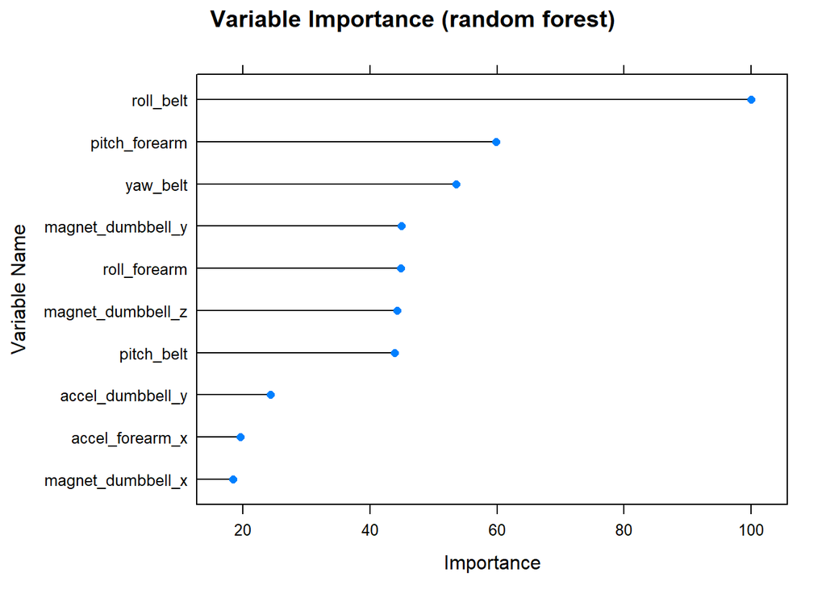

```r
# Variable importance for the random forest model
plot(varImp, top = 10, main = "Variable Importance (random forest)",
     xlab = "Importance", ylab = "Variable Name")
```

## 5.6. Cross Validation and Model Comparison

Based on the data collected above, small out of sample errors are expected. The random forest model is expected to be a bit more accurate.

```r
# Validating the models
predtb <- predict(modtb, validate) # Predicting by using the bagging model and the validation data set
predrf <- predict(modrf, validate) # Predicting by using the random forest model and the validation data set
```

```r
# Confusion matrix of the bagging model
confMatrixtb <- confusionMatrix(predtb,validate$classe)
confMatrixtb
```

```
## Confusion Matrix and Statistics
##
##           Reference
## Prediction    A    B    C    D    E
##          A 1657   15    0    1    1
##          B   12 1114    8    5    3
##          C    4    6 1008   18    3
##          D    0    1    9  940    5
##          E    1    3    1    0 1070
##
## Overall Statistics
##
##                Accuracy : 0.9837
##                  95% CI : (0.9801, 0.9868)
##     No Information Rate : 0.2845
##     P-Value [Acc > NIR] : < 2e-16
##
##                   Kappa : 0.9794
##  Mcnemar's Test P-Value : 0.06828
##
## Statistics by Class:
##
##                      Class: A Class: B Class: C Class: D Class: E
## Sensitivity            0.9898   0.9781   0.9825   0.9751   0.9889
## Specificity            0.9960   0.9941   0.9936   0.9970   0.9990
## Pos Pred Value         0.9898   0.9755   0.9702   0.9843   0.9953
## Neg Pred Value         0.9960   0.9947   0.9963   0.9951   0.9975
## Prevalence             0.2845   0.1935   0.1743   0.1638   0.1839
## Detection Rate         0.2816   0.1893   0.1713   0.1597   0.1818
## Detection Prevalence   0.2845   0.1941   0.1766   0.1623   0.1827
## Balanced Accuracy      0.9929   0.9861   0.9880   0.9860   0.9939
```

```r
# Confusion matrix of the random forest model
confMatrixrf <- confusionMatrix(predrf,validate$classe)
confMatrixrf
```

```
## Confusion Matrix and Statistics
##
##           Reference
## Prediction    A    B    C    D    E
##          A 1666    6    0    0    0
##          B    6 1131    2    2    1
##          C    1    2 1015   11    1
##          D    0    0    9  951    4
##          E    1    0    0    0 1076
##
## Overall Statistics
##
##                Accuracy : 0.9922
##                  95% CI : (0.9896, 0.9943)
##     No Information Rate : 0.2845
##     P-Value [Acc > NIR] : < 2.2e-16
##
##                   Kappa : 0.9901
##  Mcnemar's Test P-Value : NA
##
## Statistics by Class:
##
##                      Class: A Class: B Class: C Class: D Class: E
## Sensitivity            0.9952   0.9930   0.9893   0.9865   0.9945
## Specificity            0.9986   0.9977   0.9969   0.9974   0.9998
## Pos Pred Value         0.9964   0.9904   0.9854   0.9865   0.9991
## Neg Pred Value         0.9981   0.9983   0.9977   0.9974   0.9988
## Prevalence             0.2845   0.1935   0.1743   0.1638   0.1839
## Detection Rate         0.2831   0.1922   0.1725   0.1616   0.1828
## Detection Prevalence   0.2841   0.1941   0.1750   0.1638   0.1830
## Balanced Accuracy      0.9969   0.9953   0.9931   0.9919   0.9971
```

## 6. Conclusions

The original data has been cleaned by eliminating non-meaningful predictors.

The original training data set has been split into a building and a validating data sets. Two different models have been created with the first set and then validated and compared with the second set. Both models performed well and the random forest model performed a bit better than the tree bagging model. The two models gave also consistent results regarding the list of the most influential predictors.

It is worth to note that the participant id has been included among the predictors in those models. It would be interesting in future research to study how the response variable varies with the participant id and how accurate models it would be possible to get by eliminating this variable. This would be useful in order to obtain a model able to predict the quality of the execution based on the set of sensor measurements for new subjects.

<sub>R version 3.4.3 on Windows 10</sub>